# Lab4 Solutions

Rushal Sohal; github: rushalsohal

03/11/20

```r
if (!require("readxl")) {
install.packages("readxl")
}
if (!require("tidyr")) {
install.packages("tidyr")
}
if (!require("dplyr")) {
install.packages("dplyr")
}
```

```r
if (!require("ggplot2")) {
install.packages("ggplot2")
}
library(readxl)
library(tidyr)
library(dplyr)
library(ggplot2)
```

# Part 1

```r
defense <- read_excel('cyclonesFootball2019.xlsx', sheet='Defensive')
offense <- read_excel('cyclonesFootball2019.xlsx', sheet='Offensive')
bio <- read_excel('cyclonesFootball2019.xlsx', sheet='Biography')
str(bio)
```

```
## Classes 'tbl_df', 'tbl' and 'data.frame':    105 obs. of  7 variables:
##  $ Name      : chr  "Akers, Landen" "Allen, Chase" "Anderson, Ezeriah" "Assalley, Connor" ...
##  $ Position  : chr  "Wide Receiver" "Tight End" "Wide Receiver" "Placekicker" ...
##  $ Height    : chr  "6-0" "6-7" "6-5" "6-0" ...
##  $ Weight    : chr  "188" "245" "204" "195" ...
##  $ Class     : chr  "Redshirt Senior" "Redshirt Senior" "Redshirt Freshman" "Redshirt Senior" ...
##  $ Hometown  : chr  "Cedar Rapids, Iowa" "Nixa, Mo." "Seffner, Fla." "Naperville, Ill." ...
##  $ Highschool: chr  "Washington" "Nixa" "Armwood" "Central" ...
```

```r
defClean <- defense %>%
  mutate(Name = as.factor(Name),Opponent_Opponent=as.factor(Opponent_Opponent)) %>%
  mutate_at(c("Tackles_Solo","Tackles_ASST","Tackles_TFL","Tackles_Sack","Turnover_FF","Turnover_FR","Turnover_INT","Pass_QBH","Pass_PB"),as.numeric)

offClean <- offense %>%
  mutate(Name = as.factor(Name),Opponent_Opponent=as.factor(Opponent_Opponent)) %>%
  replace_na(list(.=0)) %>%
  mutate_at(c("Rushing_ATT","Rushing_YDS","Rushing_TD","Receiving_REC","Receiving_YDS","Receiving_TD","Passing_CMP-ATT","Passing_YDS","Passing_TD","Passing_INT"),as.numeric)
bioClean <- bio %>%
  separate(col=Height,into=c("Feet","Inches"),sep="-") %>%
  mutate(Name=as.factor(Name),Hometown=as.factor(Hometown),Feet=as.numeric(Feet),Inches=as.numeric(Inches),Weight=as.numeric(Weight)) %>%
  mutate(Height_Inch = Feet*12+Inches) %>%
  select(-Feet,-Inches)

str(defClean)
```

```
## Classes 'tbl_df', 'tbl' and 'data.frame':    502 obs. of  11 variables:
##  $ Name             : Factor w/ 43 levels "Akers, Landen",..: 40 40 40 40 40 40 40 40 40 40 ...
##  $ Opponent_Opponent: Factor w/ 13 levels "Baylor","Iowa",..: 12 2 11 1 8 13 10 7 6 9 ...
##  $ Tackles_Solo     : num  4 4 3 4 3 1 7 3 6 5 ...
##  $ Tackles_ASST     : num  4 7 5 2 2 1 1 2 1 5 ...
##  $ Tackles_TFL      : num  0 0 0 0 1 0 0 0 1 1 ...
##  $ Tackles_Sack     : num  0 0 0 0 0 0 0 0 0 1 ...
##  $ Turnover_FF      : num  0 0 0 0 0 0 0 0 0 0 ...
##  $ Turnover_FR      : num  0 0 0 0 0 0 0 0 0 0 ...
##  $ Turnover_INT     : num  0 0 1 0 0 0 0 0 1 0 ...
##  $ Pass_QBH         : num  1 0 0 0 0 0 0 0 1 0 ...
##  $ Pass_PB          : num  1 2 0 0 0 1 0 0 0 0 ...
```

```r
str(offClean)
```

```
## Classes 'tbl_df', 'tbl' and 'data.frame':    195 obs. of  12 variables:
##  $ Name             : Factor w/ 17 levels "Akers, Landen",..: 1 1 1 1 1 1 1 1 1 1 ...
##  $ Opponent_Opponent: Factor w/ 13 levels "Baylor","Iowa",..: 12 2 11 1 8 13 10 7 6 9 ...
##  $ Rushing_ATT      : num  0 0 1 0 0 0 0 0 0 0 ...
##  $ Rushing_YDS      : num  0 0 8 0 0 0 0 0 0 0 ...
##  $ Rushing_TD       : num  0 0 0 0 0 0 0 0 0 0 ...
##  $ Receiving_REC    : num  1 0 0 0 1 0 0 4 0 1 ...
##  $ Receiving_YDS    : num  21 0 0 0 32 0 0 39 0 7 ...
##  $ Receiving_TD     : num  0 0 0 0 0 0 0 0 0 0 ...
##  $ Passing_CMP-ATT  : num  NA NA NA NA NA NA NA NA NA NA ...
##  $ Passing_YDS      : num  NA NA NA NA NA NA NA NA NA NA ...
##  $ Passing_TD       : num  NA NA NA NA NA NA NA NA NA NA ...
##  $ Passing_INT      : num  NA NA NA NA NA NA NA NA NA NA ...
```

```r
str(bioClean)
```

```
## Classes 'tbl_df', 'tbl' and 'data.frame':    105 obs. of  7 variables:
##  $ Name       : Factor w/ 105 levels "Akers, Landen",..: 1 2 3 4 5 6 7 8 9 10 ...
##  $ Position   : chr  "Wide Receiver" "Tight End" "Wide Receiver" "Placekicker" ...
##  $ Weight     : num  188 245 204 195 190 235 255 285 300 215 ...
##  $ Class      : chr  "Redshirt Senior" "Redshirt Senior" "Redshirt Freshman" "Redshirt Senior" ...
##  $ Hometown   : Factor w/ 86 levels "Akron, Ohio",..: 16 54 73 50 36 20 41 41 86 14 ...
##  $ Highschool : chr  "Washington" "Nixa" "Armwood" "Central" ...
##  $ Height_Inch: num  72 79 77 72 72 75 74 74 72 78 ...
```

# Part 2.1

```r
#1.
defClean2 = pivot_longer(
  defClean,
  cols = Tackles_Solo:Pass_PB,
  names_to = "Statistic",
  values_to = "Count",
  values_drop_na = TRUE
)
head(defClean2)
```

```
## # A tibble: 6 x 4
##   Name            Opponent_Opponent Statistic    Count
##   <fct>           <fct>             <chr>        <dbl>
## 1 White, Lawrence UNI               Tackles_Solo     4
## 2 White, Lawrence UNI               Tackles_ASST     4
## 3 White, Lawrence UNI               Tackles_TFL      0
## 4 White, Lawrence UNI               Tackles_Sack     0
## 5 White, Lawrence UNI               Turnover_FF      0
## 6 White, Lawrence UNI               Turnover_FR      0
```

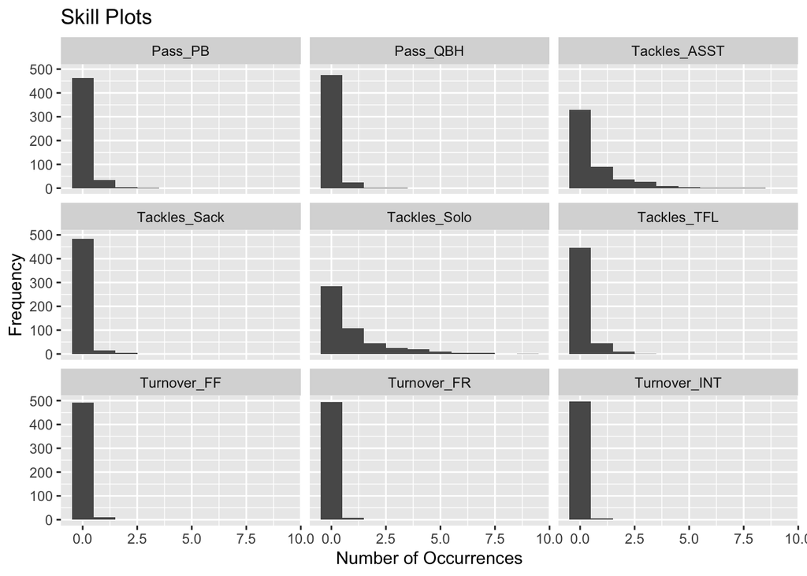

```r
#2.
ggplot(data=defClean2, aes(defClean2$Count)) +
  geom_histogram(binwidth = 1) +
  facet_wrap(~ defClean2$Statistic) + labs(title="Skill Plots",y="Frequency",x="Number of Occurrences")
```

All the items with high frequency in 0 are rare skill. For instance, Turnover_FF, Turnover_FR, Turnoner_INT, Pass_QBH are rare skills.

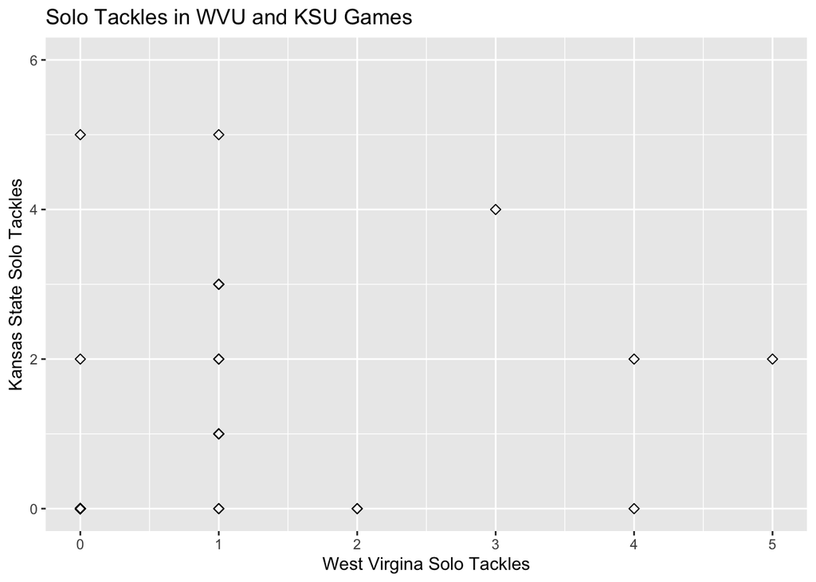

```r
defClean_3 <- defClean2 %>%
  filter(Statistic == "Tackles_Solo",Opponent_Opponent == "West Virginia" | Opponent_Opponent == "Kansas State") %>%
  select(-Statistic) %>%
  pivot_wider(names_from = Opponent_Opponent, values_from = Count)

ggplot(defClean_3, aes(x=defClean_3$`West Virginia`, y=defClean_3$`Kansas State`)) +
  geom_point(size=2, shape=23) + labs(title="Solo Tackles in WVU and KSU Games",x="West Virgina Solo Tackles",y="Kansas State Solo Tackles")
```

# Part 2.2

```r
bioClean2 = bioClean %>% separate(Hometown, c("City", "State"), sep = ",")
head(bioClean2)
```

```
## # A tibble: 6 x 8
##   Name       Position    Weight Class     City     State  Highschool Height_Inch
##   <fct>      <chr>        <dbl> <chr>     <chr>    <chr>  <chr>            <dbl>
## 1 Akers, La… Wide Recei…    188 Redshirt… Cedar R… " Iow… Washington          72
## 2 Allen, Ch… Tight End      245 Redshirt… Nixa     " Mo." Nixa                79
## 3 Anderson,… Wide Recei…    204 Redshirt… Seffner  " Fla… Armwood             77
## 4 Assalley,… Placekicker    195 Redshirt… Napervi… " Ill… Central             72
## 5 Azunna, A… Defensive …    190 Redshirt… Grand P… " Tex… Lake Ridge          72
## 6 Bailey, C… Defensive …    235 Redshirt… Clarksd… " Mis… Clarksdale          75
```

```r
w = table(bioClean2$State)
t = as.data.frame(w)
t
```

```
##          Var1 Freq
## 1       Ariz.    4
## 2        Ark.    1
## 3   Australia    1
## 4      Calif.    3
## 5        Fla.   10
## 6         Ga.    4
## 7        Ill.    5
## 8        Iowa   35
## 9        Kan.    3
## 10      Mich.    4
## 11      Minn.    4
## 12      Miss.    1
## 13        Mo.    6
## 14       Ohio    7
## 15      Okla.    2
## 16        Pa.    1
## 17       S.D.    2
## 18      Texas    6
## 19       Wis.    6
```

We can see all the state entries in the second dataframe. Iowa has the most with 35 followed by Florida with 10 entries.

# Part 3

```r
#1
bo_join <- offClean %>% left_join(bioClean,by="Name")
home <-  bo_join %>%
  select(Name,Hometown) %>% unique
home
```

```
## # A tibble: 17 x 2
##    Name                Hometown
##    <chr>               <fct>
##  1 Akers, Landen       Cedar Rapids, Iowa
##  2 Soehner, Dylan      Prairie Grove, Ark.
##  3 Allen, Chase        Nixa, Mo.
##  4 Wilson, Darren      Alpharetta, Ga.
##  5 Kolar, Charlie      Norman, Okla.
##  6 Pettway, La'Michael <NA>
##  7 Hall, Breece        Wichita, Kan.
##  8 Shaw Jr., Sean      Jones, Okla.
##  9 Purdy, Brock        Gilbert, Ariz.
## 10 Lang, Johnnie       Palmetto, Fla.
## 11 Nwangwu, Kene       Frisco, Texas
## 12 Mitchell, Re-al     <NA>
## 13 Croney Jr., Sheldon <NA>
## 14 Brock, Jirehl       Quincy, Ill.
## 15 Jones, Deshaunte    <NA>
## 16 Milton, Tarique     Bradenton, Fla.
## 17 Scates, Joe         Dayton, Ohio
```

```r
#2
prob2 <- bo_join %>%
  group_by(Name) %>%
  summarize(rec_yds=sum(Receiving_YDS))
head(prob2)
```

```
## # A tibble: 6 x 2
##   Name                rec_yds
##   <chr>                 <dbl>
## 1 Akers, Landen           109
## 2 Allen, Chase            167
## 3 Brock, Jirehl            NA
## 4 Croney Jr., Sheldon      60
## 5 Hall, Breece            252
## 6 Jones, Deshaunte        877
```

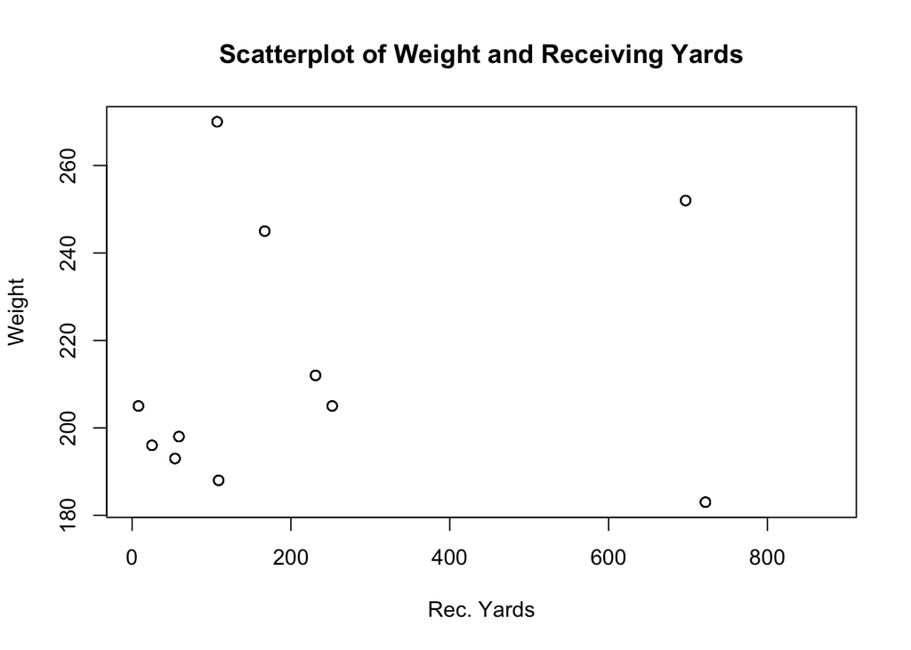

```r
prob2_join <- prob2 %>%
  left_join(bo_join,by="Name") %>%
  select(Name,rec_yds,Weight)
plot(Weight~rec_yds,data=prob2_join,main="Scatterplot of Weight and Receiving Yards",xlab="Rec. Yards")
```

We can see that there is little to no correlation between the two. Most of the points are clustered near the left corner of the graph. Moreover, one of the lightest player has the most receiving yards.

```r
#3
isu_stats <- offClean %>%
  group_by(Opponent_Opponent) %>%
  summarize(rush_att = sum(as.numeric(Rushing_ATT),na.rm=T),rush_yds = sum(Rushing_YDS,na.rm=T),rush_td = sum(Rushing_TD,na.rm=T))

head(isu_stats)
```

```
## # A tibble: 6 x 4
##   Opponent_Opponent rush_att rush_yds rush_td
##   <fct>                <dbl>    <dbl>   <dbl>
## 1 Baylor                  28       63       1
## 2 Iowa                    19       91       0
## 3 Kansas                  34      118       2
## 4 Kansas State            23       56       1
## 5 Notre Dame              27       45       0
## 6 Oklahoma                37      197       1
```

```r
isu2 <- offClean %>%
  group_by(Opponent_Opponent)
isu_stats
```

```
## # A tibble: 13 x 4
##    Opponent_Opponent rush_att rush_yds rush_td
##    <fct>                <dbl>    <dbl>   <dbl>
##  1 Baylor                  28       63       1
##  2 Iowa                    19       91       0
##  3 Kansas                  34      118       2
##  4 Kansas State            23       56       1
##  5 Notre Dame              27       45       0
##  6 Oklahoma                37      197       1
##  7 Oklahoma State          25       86       2
##  8 TCU                     34      193       4
##  9 Texas                   29      114       0
## 10 Texas Tech              23      186       2
## 11 ULM                     36      274       4
## 12 UNI                     45      185       1
## 13 West Virginia           40      146       4
```

```r
purdy <- offClean %>%
  filter(Name=="Purdy, Brock") %>%
  select(Opponent_Opponent,Passing_YDS)
combined <- isu_stats %>%
  left_join(purdy,by="Opponent_Opponent")
head(combined)
```

```
## # A tibble: 6 x 5
##   Opponent_Opponent rush_att rush_yds rush_td Passing_YDS
##   <fct>                <dbl>    <dbl>   <dbl>       <dbl>
## 1 Baylor                  28       63       1         342
## 2 Iowa                    19       91       0         276
## 3 Kansas                  34      118       2         372
## 4 Kansas State            23       56       1         185
## 5 Notre Dame              27       45       0         222
## 6 Oklahoma                37      197       1         282
```

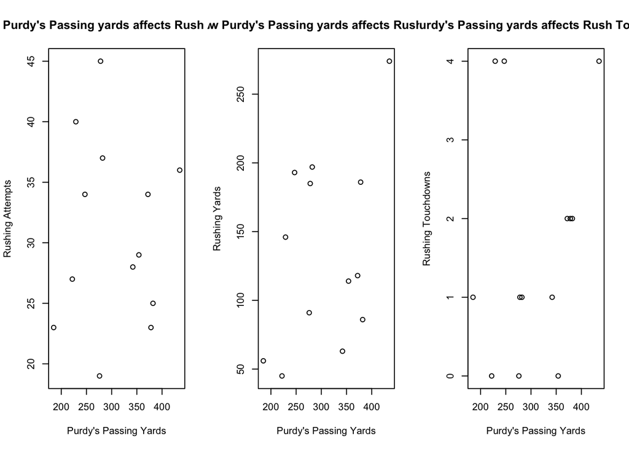

```r
par(mfrow=c(1,3))
plot(data=combined,rush_att~Passing_YDS,main="How Purdy's Passing yards affects Rush Attempts",ylab="Rushing Attempts",xlab="Purdy's Passing Yards")
plot(data=combined,rush_yds~Passing_YDS,main="How Purdy's Passing yards affects Rush Yards",ylab="Rushing Yards",xlab="Purdy's Passing Yards")
plot(data=combined,rush_td~Passing_YDS,main="How Purdy's Passing yards affects Rush Touchdowns",ylab="Rushing Touchdowns",xlab="Purdy's Passing Yards")
```

Brock Purdy is far and away the best passer on the team. Other players with non-zero passing yards never top 100 yards, while Brock tops 100 for every game.

Q> Which player averaged the most rushing yards per game and who scored the most rushing touchdowns?

```r
#4
offRushing = full_join(bioClean, offClean, by='Name') %>% group_by(Name) %>% select(Name, Rushing_YDS, Rushing_TD, Rushing_ATT)
```

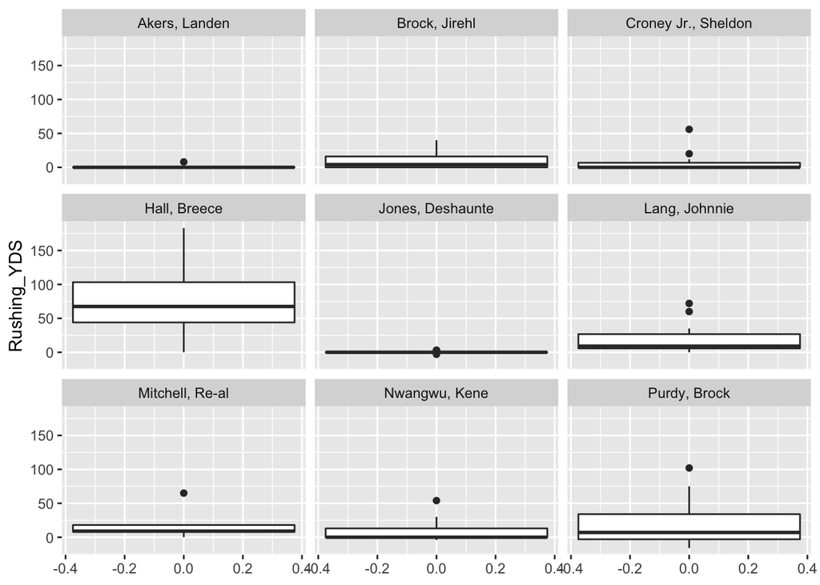

```r
offRushing = na.omit(offRushing)

ggplot(offRushing, aes(y=Rushing_YDS)) + geom_boxplot() + facet_wrap(~Name)
```

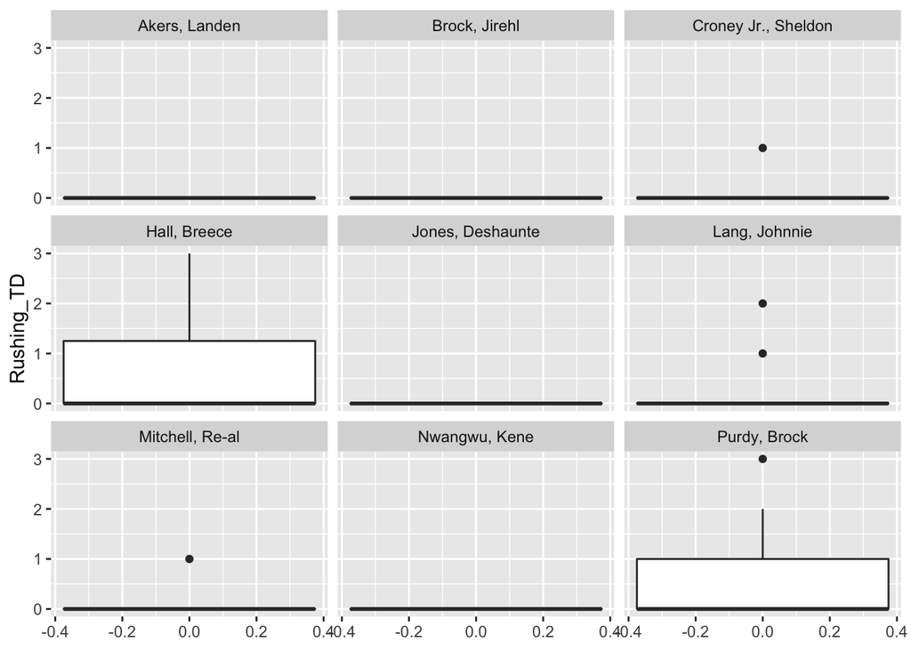

```r
ggplot(offRushing, aes(y=Rushing_TD)) + geom_boxplot() + facet_wrap(~Name)
```

Brock Purdy and Breece Hall average consistent values with higher rushing yards. Hall and Purdy have nearly identical frequency in their touchdown rates. They are also the only players to score 3 touchdowns in a game.